# One-Way ANOVA Foundations

Introduction to foundational principles of a 1-Way ANOVA.

# Introduction

Many studies, including the following examples, result in the comparison of means from more than two independent populations.

- Determine if the mean volume of white blood cells of Virginia opossums (*Didelphis virginiana*) differed by season in the same year ([Woods and Hellgren 2003](https://pubmed.ncbi.nlm.nih.gov/12905127/)).
- Determine if the mean frequency of occurrence of badgers (*Meles meles*) in plots differs between plots at different locations ([Virgos and Casanovas 1999](https://www.researchgate.net/publication/259644632_Badger_Meles_meles_sett_site_selection_in_low_density_Mediterranean_areas_of_Central_Spain)).
- Test for differences in the mean total richness of macroinvertebrates between the three zones of a river (Grubbs and Taylor 2004).
- Test if the mean mass of porcupines (*Erithizon dorsatum*) differs among months of summer ([Sweitzer and Berger 1992](https://esajournals.onlinelibrary.wiley.com/doi/abs/10.2307/1940164)).
- Test if the mean clutch size of spiders differs among three types of parental care categories (Simpson 1995).
- Determine if the mean age of harvested deer (*Odocoelius virginianus*) differs among Ashland, Bayfield, Douglas, and Iron counties.

In each of these situations, the mean of a quantitative variable (e.g., age, frequency of occurrence, total richness, or body mass) is compared among two or more populations of a single factor variable (e.g., county, locations, zones, or season). A 2-sample t-test cannot be used in these situations because more than two groups are compared. A one-way analysis of variance (or **one-way ANOVA**) is simply an extension of a 2-sample t-test and can be used for each of these situations.[^1]

A one-way analysis of variance (ANOVA) is used to determine if a significant difference exists among the means of more than two populations.

### Data

The data for a one-way ANOVA must be stacked as described for the 2-sample t-test. In this module, we examine the immunoglobulin[^2] measurements of opossums (`imm`) during three months of the same year (`season`). The data are loaded into R and a subset of rows is shown below.

Data must be stacked!!

```
opp <- read.csv("Opossums.csv")
```

```
head(opp)
```

```
#R>       imm season
#R>   1 0.640    feb
#R>   2 0.680    feb
#R>   3 0.731    feb
#R>   4 0.587    feb
#R>   5 0.668    feb
#R>   6 0.613    feb
```

# Analytical Foundation

The generic null hypothesis for a one-way ANOVA is

$$\text{H}_{\text{0}}: \mu_{1} = \mu_{2} = \ldots = \mu_{I}$$

where $I$ is the total number of groups or populations.[^3] The alternative hypothesis is complicated because not all pairs of means need differ for the null hypothesis to be rejected. Thus, the alternative hypothesis for a one-way ANOVA is “wordy” and is often written as

$$\text{H}_{\text{A}}:\text{At least one pair of means is different}$$

A rejection of H<sub>0</sub> in favor of H<sub>A</sub> is a statement that *some* difference in group means exists. It does not clearly indicate which group means differ. Methods to identify which group means differ are in the Multiple Comparisons module.

Rejecting H<sub>0</sub> **just** means that **some** group means differ.

The simple ($Y_{ij} = \mu + \epsilon_{ij}$) and full ($Y_{ij} = \mu_{i} + \epsilon_{ij}$) models for the one-way ANOVA are the same as those for the 2-sample t-test, except that there are $I$>2 means in the full model. Thus, SS<sub>total</sub>, SS<sub>within</sub>, and SS<sub>among</sub> are computed using the same formulae shown in the Model Comparision module, except to again note that $I$>2. The degrees-of-freedom are also computed similarly – i.e., df<sub>Within</sub>=$n$-$I$ and df<sub>Among</sub>=$I$-1. The MS, F, and p-value are also computed in the same way.[^4]

A 2-Sample t-Test is simply a special case of a One-Way ANOVA.

Figure 1 is a visual for simple and full models and residuals from each. Note the similarity with figures from the Model Comparison module, except that there are three group means here.

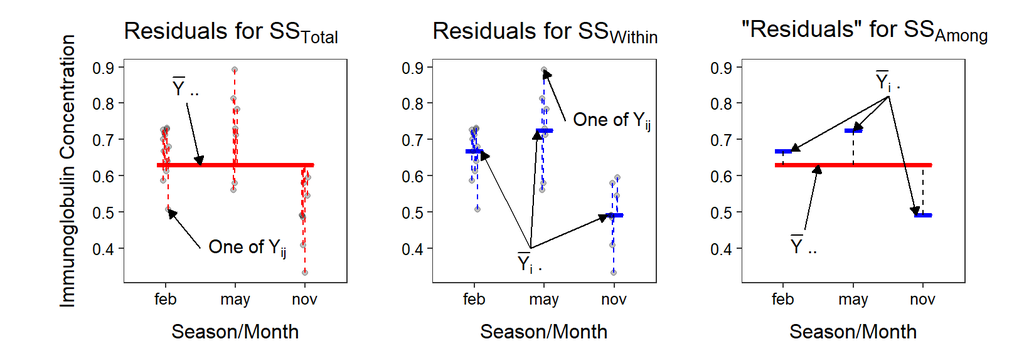

Figure 1: Immunoglobulin concentrations versus season (or month) of capture for New Zealand opposums. The grand mean is shown by a red horizontal segment, group means are shown by blue horizontal segments, residuals from the grand mean are red vertical dashed lines, residuals from the groups means are blue vertical dashed lines, and differnces between the group means and the grand mean are black vertical dashed lines.

An ANOVA table (Table 1) is use to display the results from a one-way ANOVA, because the one-way ANOVA is simply a comparison of two models.

Table 1: An ANOVA table for immunoglobuling concentration by season (or month) for New Zealand opossums. Note that the “Total” row is not shown.

|  | Df | Sum Sq | Mean Sq | F value | Pr(>F) |
| --- | --- | --- | --- | --- | --- |
| season | 2 | 0.2340 | 0.1170 | 14.4486 | 1e-04 |
| Residuals | 24 | 0.1944 | 0.0081 |  |  |

In addition to the usual meanings attached to MS<sub>Among</sub>, MS<sub>Among</sub>, and MS<sub>Total</sub>,[^5] the following can be discerned from this ANOVA table.

- df<sub>Among</sub>=2 and because df<sub>Among</sub>=$I$-1, then $I$=3. This confirms that there are three groups in this analysis.
- df<sub>Total</sub>=df<sub>Among</sub>+df<sub>Within</sub>=2+24=26. Because df<sub>Total</sub>=$n$-1, then $n$=27. This shows that there are 27 individuals in this analysis.
- There is a significant difference in the mean immunoglobulin values among the three months because the p-value=0.0001<α.

# Using R

The models for a one-way ANOVA are fit and assessed with `lm()` exactly as described for a 2-sample t-test. As a reminder, a formula of `response~factor` is the first argument and a data.frame is given in `data=` in `lm()`, the results of `lm()` should be assigned to an object, and the ANOVA table is extracted with `anova()`.

The `lm()` code is the same for a 2-Sample t-Test and a One-Way ANOVA.

```
lm1 <- lm(imm~season,data=opp)
anova(lm1)
```

```
#R>   Analysis of Variance Table
#R>
#R>   Response: imm
#R>             Df  Sum Sq  Mean Sq F value    Pr(>F)
#R>   season     2 0.23401 0.117005  14.449 7.609e-05
#R>   Residuals 24 0.19435 0.008098
```

A graphic that illustrates the mean immunoglobulin value with 95% confidence intervals for each month is constructed below (as shown here).

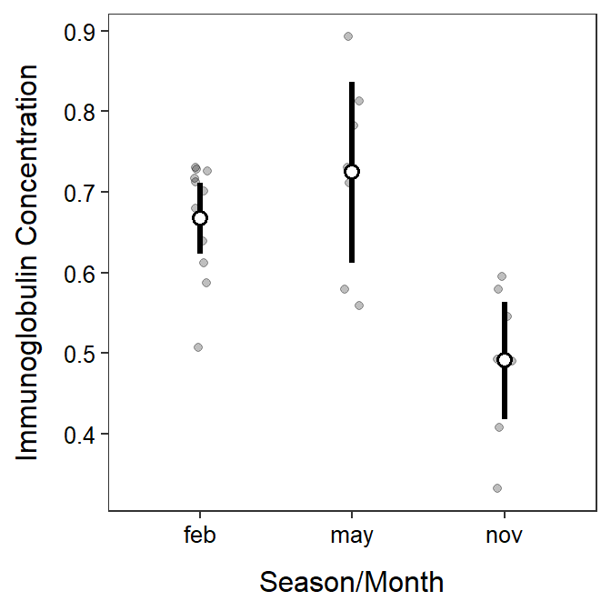

```
ggplot(data=opp,mapping=aes(x=season,y=imm)) +
  geom_jitter(alpha=0.25,width=0.05) +
  stat_summary(fun.data=mean_cl_normal,geom="pointrange",
               size=1.1,fatten=2,pch=21,fill="white") +
  labs(y="Immunoglobulin Concentration",x="Season/Month") +
  theme_NCStats()
```

# Corrections

If you see any errors (code, typographical, or logical) please bring these to my attention.

[^1]: This and the next several modules depends heavily on the foundational material in the previous modules, especially the concepts of simple and full models; “signal” and “noise”; variances explained and unexplained; and SS, MS, F, and p-values.
[^2]: Any of a class of proteins present in the serum and cells of the immune system, which function as antibodies.
[^3]: From this, it is evident that the one-way ANOVA is a direct extension of the 2-sample t-test.
[^4]: The MS, F, and p-value are computed the same in nearly every ANOVA table encountered in this class.
[^5]: Note that MS<sub>Total</sub> **must** be computed from SS<sub>Total</sub> and df<sub>Total</sub> and not by summing MS<sub>Among</sub> an MS<sub>Within</sub>.